# Risk Factor Analysis

## Outcome Variable

**Outcome Variable:** haz

## Predictor Variables

**Intervention Variable:** gagebrth

**Adjustment Set:**

- arm
- sex
- W_mage
- meducyrs
- feducyrs
- hhwealth_quart
- W_nrooms
- brthmon
- W_parity
- impsan
- delta_W_mage
- delta_meducyrs
- delta_feducyrs
- delta_hhwealth_quart
- delta_W_nrooms
- delta_brthmon
- delta_W_parity
- delta_impsan

## Stratifying Variables

The analysis was stratified on these variable(s):

- agecat
- studyid
- country

## Data Summary

| agecat | studyid | country | gagebrth | n_cell | n | outcome_variable |
| --- | --- | --- | --- | --- | --- | --- |
| Birth | CMC-V-BCS-2002 | INDIA | Full or late term | 58 | 92 | haz |
| Birth | CMC-V-BCS-2002 | INDIA | Preterm | 11 | 92 | haz |
| Birth | CMC-V-BCS-2002 | INDIA | Early term | 23 | 92 | haz |
| Birth | COHORTS | GUATEMALA | Full or late term | 341 | 617 | haz |
| Birth | COHORTS | GUATEMALA | Preterm | 95 | 617 | haz |
| Birth | COHORTS | GUATEMALA | Early term | 181 | 617 | haz |
| Birth | COHORTS | INDIA | Full or late term | 570 | 1293 | haz |
| Birth | COHORTS | INDIA | Preterm | 285 | 1293 | haz |
| Birth | COHORTS | INDIA | Early term | 438 | 1293 | haz |
| Birth | COHORTS | PHILIPPINES | Full or late term | 1164 | 3024 | haz |
| Birth | COHORTS | PHILIPPINES | Preterm | 649 | 3024 | haz |
| Birth | COHORTS | PHILIPPINES | Early term | 1211 | 3024 | haz |
| Birth | IRC | INDIA | Full or late term | 238 | 369 | haz |
| Birth | IRC | INDIA | Preterm | 36 | 369 | haz |
| Birth | IRC | INDIA | Early term | 95 | 369 | haz |
| Birth | JiVitA-3 | BANGLADESH | Full or late term | 10944 | 21442 | haz |
| Birth | JiVitA-3 | BANGLADESH | Preterm | 4514 | 21442 | haz |
| Birth | JiVitA-3 | BANGLADESH | Early term | 5984 | 21442 | haz |
| Birth | Keneba | GAMBIA | Full or late term | 734 | 1515 | haz |
| Birth | Keneba | GAMBIA | Preterm | 235 | 1515 | haz |
| Birth | Keneba | GAMBIA | Early term | 546 | 1515 | haz |
| Birth | NIH-Crypto | BANGLADESH | Full or late term | 162 | 732 | haz |
| Birth | NIH-Crypto | BANGLADESH | Preterm | 257 | 732 | haz |
| Birth | NIH-Crypto | BANGLADESH | Early term | 313 | 732 | haz |
| Birth | PROBIT | BELARUS | Full or late term | 7100 | 13893 | haz |
| Birth | PROBIT | BELARUS | Preterm | 472 | 13893 | haz |
| Birth | PROBIT | BELARUS | Early term | 6321 | 13893 | haz |
| 6 months | CMC-V-BCS-2002 | INDIA | Full or late term | 212 | 347 | haz |
| 6 months | CMC-V-BCS-2002 | INDIA | Preterm | 52 | 347 | haz |
| 6 months | CMC-V-BCS-2002 | INDIA | Early term | 83 | 347 | haz |

[output cut: 57 more lines]

The following strata were considered:

- agecat: 24 months, studyid: CMC-V-BCS-2002, country: INDIA
- agecat: 24 months, studyid: COHORTS, country: GUATEMALA
- agecat: 24 months, studyid: COHORTS, country: INDIA
- agecat: 24 months, studyid: COHORTS, country: PHILIPPINES
- agecat: 24 months, studyid: IRC, country: INDIA
- agecat: 24 months, studyid: JiVitA-3, country: BANGLADESH
- agecat: 24 months, studyid: Keneba, country: GAMBIA
- agecat: 24 months, studyid: NIH-Crypto, country: BANGLADESH
- agecat: 24 months, studyid: PROBIT, country: BELARUS
- agecat: 24 months, studyid: TanzaniaChild2, country: TANZANIA, UNITED REPUBLIC OF
- agecat: 6 months, studyid: CMC-V-BCS-2002, country: INDIA
- agecat: 6 months, studyid: COHORTS, country: GUATEMALA
- agecat: 6 months, studyid: COHORTS, country: INDIA
- agecat: 6 months, studyid: COHORTS, country: PHILIPPINES
- agecat: 6 months, studyid: IRC, country: INDIA
- agecat: 6 months, studyid: JiVitA-3, country: BANGLADESH
- agecat: 6 months, studyid: Keneba, country: GAMBIA
- agecat: 6 months, studyid: NIH-Crypto, country: BANGLADESH
- agecat: 6 months, studyid: PROBIT, country: BELARUS
- agecat: 6 months, studyid: TanzaniaChild2, country: TANZANIA, UNITED REPUBLIC OF
- agecat: Birth, studyid: CMC-V-BCS-2002, country: INDIA
- agecat: Birth, studyid: COHORTS, country: GUATEMALA
- agecat: Birth, studyid: COHORTS, country: INDIA
- agecat: Birth, studyid: COHORTS, country: PHILIPPINES
- agecat: Birth, studyid: IRC, country: INDIA
- agecat: Birth, studyid: JiVitA-3, country: BANGLADESH
- agecat: Birth, studyid: Keneba, country: GAMBIA
- agecat: Birth, studyid: NIH-Crypto, country: BANGLADESH
- agecat: Birth, studyid: PROBIT, country: BELARUS

### Dropped Strata

Some strata were dropped due to rare outcomes:

- agecat: 24 months, studyid: TanzaniaChild2, country: TANZANIA, UNITED REPUBLIC OF

## Methods Detail

We’re interested in the causal parameters $E[Y_a]$ for all values of $a \in \mathcal{A}$. These parameters represent the mean outcome if, possibly contrary to fact, we intervened to set all units to have $A=a$. Under the randomization and positivity assumptions, these are identified by the statistical parameters $\psi_a=E_W[E_{Y|A,W}(Y|A=a,W)]$. In addition, we’re interested in the mean of $Y$, $E[Y]$ under no intervention (the observed mean). We will estimate these parameters by using SuperLearner to fit the relevant likelihood factors – $E_{Y|A,W}(Y|A=a,W)$ and $p(A=a|W)$, and then updating our likelihood fit using a joint TMLE.

For unadjusted analyses ($W=\{\}$), initial likelihoods were estimated using Lrnr_glm to estimate the simple $E(Y|A)$ and Lrnr_mean to estimate $p(A)$. For adjusted analyses, a small library containing Lrnr_glmnet, Lrnr_xgboost, and Lrnr_mean was used.

Having estimated these parameters, we will then use the delta method to estimate relative risks and attributable risks relative to a prespecified baseline level of $A$.

# Results Detail

## Results Plots

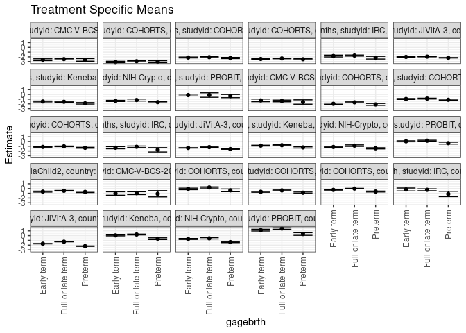

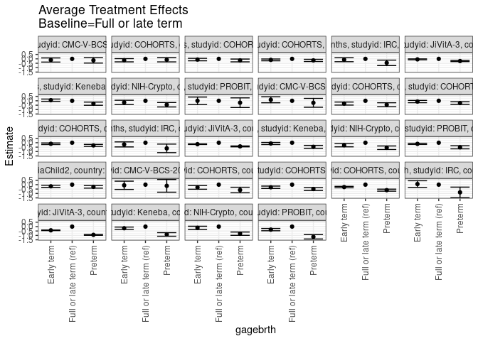

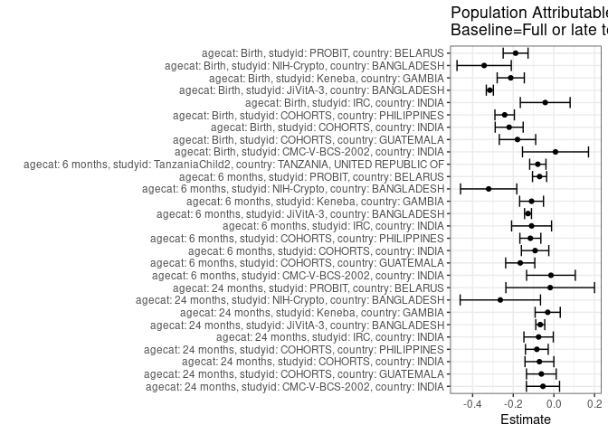

## Results Table

### Parameter: TSM

| agecat | studyid | country | intervention_level | baseline_level | estimate | ci_lower | ci_upper |
| --- | --- | --- | --- | --- | --- | --- | --- |
| Birth | CMC-V-BCS-2002 | INDIA | Full or late term | NA | -0.9690937 | -1.2663925 | -0.6717950 |
| Birth | CMC-V-BCS-2002 | INDIA | Preterm | NA | -1.1046548 | -1.7579682 | -0.4513414 |
| Birth | CMC-V-BCS-2002 | INDIA | Early term | NA | -1.0407982 | -1.4030018 | -0.6785946 |
| Birth | COHORTS | GUATEMALA | Full or late term | NA | 0.2322238 | 0.1075980 | 0.3568495 |
| Birth | COHORTS | GUATEMALA | Preterm | NA | -0.3753694 | -0.6643969 | -0.0863419 |
| Birth | COHORTS | GUATEMALA | Early term | NA | -0.0775900 | -0.2444015 | 0.0892215 |
| Birth | COHORTS | INDIA | Full or late term | NA | -0.3871873 | -0.4761943 | -0.2981803 |
| Birth | COHORTS | INDIA | Preterm | NA | -0.8808832 | -1.0241400 | -0.7376264 |
| Birth | COHORTS | INDIA | Early term | NA | -0.6837297 | -0.7842137 | -0.5832457 |
| Birth | COHORTS | PHILIPPINES | Full or late term | NA | -0.0069068 | -0.0651415 | 0.0513279 |
| Birth | COHORTS | PHILIPPINES | Preterm | NA | -0.6308995 | -0.7283596 | -0.5334394 |
| Birth | COHORTS | PHILIPPINES | Early term | NA | -0.2812704 | -0.3380634 | -0.2244775 |
| Birth | IRC | INDIA | Full or late term | NA | -0.2676666 | -0.4722078 | -0.0631253 |
| Birth | IRC | INDIA | Preterm | NA | -1.1432855 | -1.7013015 | -0.5852694 |
| Birth | IRC | INDIA | Early term | NA | -0.1983354 | -0.5108999 | 0.1142291 |
| Birth | JiVitA-3 | BANGLADESH | Full or late term | NA | -1.2828858 | -1.3063016 | -1.2594700 |
| Birth | JiVitA-3 | BANGLADESH | Preterm | NA | -2.2197685 | -2.2642046 | -2.1753324 |
| Birth | JiVitA-3 | BANGLADESH | Early term | NA | -1.7048048 | -1.7352992 | -1.6743104 |
| Birth | Keneba | GAMBIA | Full or late term | NA | 0.2402424 | 0.1539908 | 0.3264941 |
| Birth | Keneba | GAMBIA | Preterm | NA | -0.6510665 | -0.8344660 | -0.4676670 |
| Birth | Keneba | GAMBIA | Early term | NA | 0.0537517 | -0.0480247 | 0.1555281 |
| Birth | NIH-Crypto | BANGLADESH | Full or late term | NA | -0.5663502 | -0.7159884 | -0.4167121 |
| Birth | NIH-Crypto | BANGLADESH | Preterm | NA | -1.3707340 | -1.4829232 | -1.2585449 |
| Birth | NIH-Crypto | BANGLADESH | Early term | NA | -0.7094953 | -0.8135591 | -0.6054314 |
| Birth | PROBIT | BELARUS | Full or late term | NA | 1.4998051 | 1.3453604 | 1.6542499 |
| Birth | PROBIT | BELARUS | Preterm | NA | 0.3421522 | 0.0639243 | 0.6203801 |
| Birth | PROBIT | BELARUS | Early term | NA | 1.1559979 | 0.9701805 | 1.3418153 |
| 6 months | CMC-V-BCS-2002 | INDIA | Full or late term | NA | -1.3711874 | -1.5555405 | -1.1868344 |
| 6 months | CMC-V-BCS-2002 | INDIA | Preterm | NA | -1.6010376 | -2.0674369 | -1.1346383 |
| 6 months | CMC-V-BCS-2002 | INDIA | Early term | NA | -1.2580240 | -1.5421019 | -0.9739461 |

[output cut: 54 more lines]

### Parameter: E(Y)

| agecat | studyid | country | intervention_level | baseline_level | estimate | ci_lower | ci_upper |
| --- | --- | --- | --- | --- | --- | --- | --- |
| Birth | CMC-V-BCS-2002 | INDIA | NA | NA | -0.9611957 | -1.1776967 | -0.7446946 |
| Birth | COHORTS | GUATEMALA | NA | NA | 0.0530794 | -0.0441925 | 0.1503513 |
| Birth | COHORTS | INDIA | NA | NA | -0.6072158 | -0.6675691 | -0.5468624 |
| Birth | COHORTS | PHILIPPINES | NA | NA | -0.2492460 | -0.2884729 | -0.2100192 |
| Birth | IRC | INDIA | NA | NA | -0.3102981 | -0.4751168 | -0.1454794 |
| Birth | JiVitA-3 | BANGLADESH | NA | NA | -1.5980879 | -1.6176172 | -1.5785586 |
| Birth | Keneba | GAMBIA | NA | NA | 0.0278680 | -0.0365315 | 0.0922674 |
| Birth | NIH-Crypto | BANGLADESH | NA | NA | -0.9094945 | -0.9809370 | -0.8380521 |
| Birth | PROBIT | BELARUS | NA | NA | 1.3114417 | 1.1524752 | 1.4704082 |
| 6 months | CMC-V-BCS-2002 | INDIA | NA | NA | -1.3856004 | -1.5319935 | -1.2392073 |
| 6 months | COHORTS | GUATEMALA | NA | NA | -1.8315428 | -1.9081267 | -1.7549589 |
| 6 months | COHORTS | INDIA | NA | NA | -0.9630335 | -1.0220763 | -0.9039908 |
| 6 months | COHORTS | PHILIPPINES | NA | NA | -1.1409862 | -1.1830414 | -1.0989310 |
| 6 months | IRC | INDIA | NA | NA | -1.2321263 | -1.3660720 | -1.0981806 |
| 6 months | JiVitA-3 | BANGLADESH | NA | NA | -1.3168751 | -1.3402193 | -1.2935309 |
| 6 months | Keneba | GAMBIA | NA | NA | -0.8948084 | -0.9510697 | -0.8385471 |
| 6 months | NIH-Crypto | BANGLADESH | NA | NA | -1.1986783 | -1.2700937 | -1.1272630 |
| 6 months | PROBIT | BELARUS | NA | NA | 0.0980074 | 0.0062724 | 0.1897424 |
| 6 months | TanzaniaChild2 | TANZANIA, UNITED REPUBLIC OF | NA | NA | -0.5419570 | -0.5926042 | -0.4913098 |
| 24 months | CMC-V-BCS-2002 | INDIA | NA | NA | -2.5319389 | -2.6335015 | -2.4303762 |
| 24 months | COHORTS | GUATEMALA | NA | NA | -2.9911195 | -3.0733804 | -2.9088586 |
| 24 months | COHORTS | INDIA | NA | NA | -2.1289450 | -2.1901830 | -2.0677069 |
| 24 months | COHORTS | PHILIPPINES | NA | NA | -2.4144884 | -2.4596605 | -2.3693164 |
| 24 months | IRC | INDIA | NA | NA | -1.7964915 | -1.8912047 | -1.7017782 |
| 24 months | JiVitA-3 | BANGLADESH | NA | NA | -2.0156596 | -2.0439781 | -1.9873411 |
| 24 months | Keneba | GAMBIA | NA | NA | -1.5800865 | -1.6398819 | -1.5202911 |
| 24 months | NIH-Crypto | BANGLADESH | NA | NA | -1.4412646 | -1.5249156 | -1.3576135 |
| 24 months | PROBIT | BELARUS | NA | NA | -0.1442891 | -0.4253755 | 0.1367972 |

### Parameter: ATE

| agecat | studyid | country | intervention_level | baseline_level | estimate | ci_lower | ci_upper |
| --- | --- | --- | --- | --- | --- | --- | --- |
| Birth | CMC-V-BCS-2002 | INDIA | Full or late term | Full or late term | 0.0000000 | 0.0000000 | 0.0000000 |
| Birth | CMC-V-BCS-2002 | INDIA | Preterm | Full or late term | -0.1355611 | -0.8560327 | 0.5849105 |
| Birth | CMC-V-BCS-2002 | INDIA | Early term | Full or late term | -0.0717044 | -0.5404320 | 0.3970231 |
| Birth | COHORTS | GUATEMALA | Full or late term | Full or late term | 0.0000000 | 0.0000000 | 0.0000000 |
| Birth | COHORTS | GUATEMALA | Preterm | Full or late term | -0.6075931 | -0.9226191 | -0.2925671 |
| Birth | COHORTS | GUATEMALA | Early term | Full or late term | -0.3098138 | -0.5183387 | -0.1012889 |
| Birth | COHORTS | INDIA | Full or late term | Full or late term | 0.0000000 | 0.0000000 | 0.0000000 |
| Birth | COHORTS | INDIA | Preterm | Full or late term | -0.4936959 | -0.6625113 | -0.3248805 |
| Birth | COHORTS | INDIA | Early term | Full or late term | -0.2965424 | -0.4304624 | -0.1626224 |
| Birth | COHORTS | PHILIPPINES | Full or late term | Full or late term | 0.0000000 | 0.0000000 | 0.0000000 |
| Birth | COHORTS | PHILIPPINES | Preterm | Full or late term | -0.6239927 | -0.7373051 | -0.5106804 |
| Birth | COHORTS | PHILIPPINES | Early term | Full or late term | -0.2743637 | -0.3554100 | -0.1933173 |
| Birth | IRC | INDIA | Full or late term | Full or late term | 0.0000000 | 0.0000000 | 0.0000000 |
| Birth | IRC | INDIA | Preterm | Full or late term | -0.8756189 | -1.4708741 | -0.2803637 |
| Birth | IRC | INDIA | Early term | Full or late term | 0.0693311 | -0.3051358 | 0.4437981 |
| Birth | JiVitA-3 | BANGLADESH | Full or late term | Full or late term | 0.0000000 | 0.0000000 | 0.0000000 |
| Birth | JiVitA-3 | BANGLADESH | Preterm | Full or late term | -0.9368827 | -0.9873908 | -0.8863746 |
| Birth | JiVitA-3 | BANGLADESH | Early term | Full or late term | -0.4219190 | -0.4574834 | -0.3863546 |
| Birth | Keneba | GAMBIA | Full or late term | Full or late term | 0.0000000 | 0.0000000 | 0.0000000 |
| Birth | Keneba | GAMBIA | Preterm | Full or late term | -0.8913089 | -1.0940118 | -0.6886061 |
| Birth | Keneba | GAMBIA | Early term | Full or late term | -0.1864907 | -0.3198703 | -0.0531112 |
| Birth | NIH-Crypto | BANGLADESH | Full or late term | Full or late term | 0.0000000 | 0.0000000 | 0.0000000 |
| Birth | NIH-Crypto | BANGLADESH | Preterm | Full or late term | -0.8043838 | -0.9916243 | -0.6171433 |
| Birth | NIH-Crypto | BANGLADESH | Early term | Full or late term | -0.1431450 | -0.3254507 | 0.0391606 |
| Birth | PROBIT | BELARUS | Full or late term | Full or late term | 0.0000000 | 0.0000000 | 0.0000000 |
| Birth | PROBIT | BELARUS | Preterm | Full or late term | -1.1576529 | -1.4030361 | -0.9122698 |
| Birth | PROBIT | BELARUS | Early term | Full or late term | -0.3438073 | -0.4751655 | -0.2124490 |
| 6 months | CMC-V-BCS-2002 | INDIA | Full or late term | Full or late term | 0.0000000 | 0.0000000 | 0.0000000 |
| 6 months | CMC-V-BCS-2002 | INDIA | Preterm | Full or late term | -0.2298502 | -0.7310349 | 0.2713344 |
| 6 months | CMC-V-BCS-2002 | INDIA | Early term | Full or late term | 0.1131634 | -0.2260454 | 0.4523721 |

[output cut: 54 more lines]

### Parameter: PAR

| agecat | studyid | country | intervention_level | baseline_level | estimate | ci_lower | ci_upper |
| --- | --- | --- | --- | --- | --- | --- | --- |
| Birth | CMC-V-BCS-2002 | INDIA | Full or late term | NA | 0.0078981 | -0.1545875 | 0.1703837 |
| Birth | COHORTS | GUATEMALA | Full or late term | NA | -0.1791443 | -0.2686993 | -0.0895894 |
| Birth | COHORTS | INDIA | Full or late term | NA | -0.2200284 | -0.2888544 | -0.1512025 |
| Birth | COHORTS | PHILIPPINES | Full or late term | NA | -0.2423393 | -0.2901992 | -0.1944793 |
| Birth | IRC | INDIA | Full or late term | NA | -0.0426315 | -0.1651718 | 0.0799087 |
| Birth | JiVitA-3 | BANGLADESH | Full or late term | NA | -0.3152020 | -0.3326221 | -0.2977820 |
| Birth | Keneba | GAMBIA | Full or late term | NA | -0.2123745 | -0.2791223 | -0.1456266 |
| Birth | NIH-Crypto | BANGLADESH | Full or late term | NA | -0.3431443 | -0.4767329 | -0.2095557 |
| Birth | PROBIT | BELARUS | Full or late term | NA | -0.1883634 | -0.2495766 | -0.1271502 |
| 6 months | CMC-V-BCS-2002 | INDIA | Full or late term | NA | -0.0144130 | -0.1343442 | 0.1055183 |
| 6 months | COHORTS | GUATEMALA | Full or late term | NA | -0.1656076 | -0.2373222 | -0.0938930 |
| 6 months | COHORTS | INDIA | Full or late term | NA | -0.0924327 | -0.1598785 | -0.0249868 |
| 6 months | COHORTS | PHILIPPINES | Full or late term | NA | -0.1157964 | -0.1673864 | -0.0642064 |
| 6 months | IRC | INDIA | Full or late term | NA | -0.1098060 | -0.2081317 | -0.0114803 |
| 6 months | JiVitA-3 | BANGLADESH | Full or late term | NA | -0.1272817 | -0.1443034 | -0.1102599 |
| 6 months | Keneba | GAMBIA | Full or late term | NA | -0.1098943 | -0.1686213 | -0.0511674 |
| 6 months | NIH-Crypto | BANGLADESH | Full or late term | NA | -0.3209906 | -0.4594863 | -0.1824950 |
| 6 months | PROBIT | BELARUS | Full or late term | NA | -0.0705071 | -0.1053155 | -0.0356987 |
| 6 months | TanzaniaChild2 | TANZANIA, UNITED REPUBLIC OF | Full or late term | NA | -0.0790635 | -0.1191080 | -0.0390190 |
| 24 months | CMC-V-BCS-2002 | INDIA | Full or late term | NA | -0.0536466 | -0.1352316 | 0.0279384 |
| 24 months | COHORTS | GUATEMALA | Full or late term | NA | -0.0616839 | -0.1348829 | 0.0115151 |
| 24 months | COHORTS | INDIA | Full or late term | NA | -0.0711265 | -0.1421231 | -0.0001299 |
| 24 months | COHORTS | PHILIPPINES | Full or late term | NA | -0.0839073 | -0.1398811 | -0.0279335 |
| 24 months | IRC | INDIA | Full or late term | NA | -0.0751964 | -0.1474411 | -0.0029517 |
| 24 months | JiVitA-3 | BANGLADESH | Full or late term | NA | -0.0670770 | -0.0892147 | -0.0449393 |
| 24 months | Keneba | GAMBIA | Full or late term | NA | -0.0304813 | -0.0922414 | 0.0312787 |
| 24 months | NIH-Crypto | BANGLADESH | Full or late term | NA | -0.2635470 | -0.4612648 | -0.0658293 |
| 24 months | PROBIT | BELARUS | Full or late term | NA | -0.0181959 | -0.2363310 | 0.1999392 |